# First Hybrid GIS Tests

03-28-2017

First tests of the USAMS SNICS-134 Hybrid gas ion source.

```r
library(amstools)
library(tidyverse)
library(ggplot2)
```

# Flow rates

## Calculated flow

### Pouiselles equation

$$Q = \frac{\Delta P \pi R^4}{8 \mu \Delta x}$$
Where $\Delta P$ is change in pressure (Pa ($\frac{kg}{m \cdot s^2}$)), $R$ is radius of pipe (m), $\mu$ is dynamic viscosity ( $P \cdot s$ ($\frac{kg}{s \cdot m}$)), and $\Delta x$ is the length of the pipe (m). Q is in $\frac{m^3}{s}$

## measured flow

### Leak detector

Measured leak rate using Helium leak detector. Ran capillary to KF adapter flange. Pressures in kPa, leak rates in $\frac{Pa\cdot m^3}{s}$. Leak detector switched to gross leak mode between 150 kPa and 200 kPa.

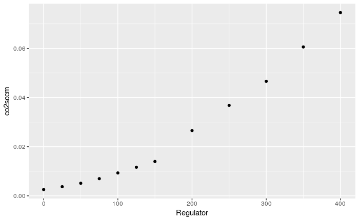

## Functions for flow and efficiency

```r
# convert L CO2 to atoms C
lCO2toatC <- function (vol) {
  molC <- vol * 1/22.4 # 22.4 L of gas per mole at stp
  atC <- molC * 6.022E23
  atC
}
# convert current in A to atoms C/sec
CcurtoatC <- function(cur, cs){
  at12C <- cur * 6.25E18 # electrons per coulomb
  at12C <- at12C / cs # divide by charge state
  at12C
}
# convert delta pressure in Pa to flow in m^3/s
prestoflow <- function(dp, r = 2.5E-5, u = 1.49E-5, l = 8.2 ) {
  # r = radius of capillary
  # l = length of capillary
  # u = viscosity kg/m
  flow <- dp * pi * r^4 / 8 / u / l
  flow
}
# convert gauge kPa to uL/min
flowcalc <- function(pres) {
  dppa <- pres * 1E3 #convert kPa to Pa
  flowcms <- prestoflow(dppa)
  flowuls <- flowcms * 1E6 * 1E3
  flowulm <- flowuls * 60
  flowulm
}
# calculate efficiency from ml/m CO2 and uA C12
hgis_eff <- function(ulm, uA, cs = 3) {

  # if flow is zero or less, efficiency doesn't make sense
  ulm <- ifelse(ulm <= 0, NA, ulm)

  vol <- ulm * 1E-6 # conv to L
  cur <- uA * 1E-6 # conv to A
  atCin <- lCO2toatC(vol) / 60 # gives atoms/s
  atC12out <- CcurtoatC(cur, cs)
  atCout <- atC12out / .99 # 99% of C is 12C, we need total C
  atC12out / atCin
}
```

# First Day

USAMS032817

```r
data <- readResfile("/mnt/shared/USAMS/Results/USAMS032817R.txt") %>%
  mungeResfile()
```

## Currents

For the first target, we turned up the gas supply pressure while measuring source current at the high energy FC. These currents are roughly equivalent to le12C.

```r
cur <- read.delim("1sttestcurrents.csv") %>%
  mutate(flow = flowcalc(regp),
         eff = hgis_eff(flow, he12c)) %>%
  filter(t > 5)
cur
```

| t | regp | sourcep | he12c | c1412 | flow | eff |
| --- | --- | --- | --- | --- | --- | --- |
| 10 | 0 | 3.0e-07 | 1.2 | 1.10 | 0.0000000 | NA |
| 13 | 5 | 3.2e-07 | 1.4 | 1.00 | 0.3766527 | 0.017282408 |
| 15 | 10 | 3.5e-07 | 2.2 | 1.10 | 0.7533053 | 0.013579035 |
| 20 | 50 | 3.9e-07 | 3.2 | 1.03 | 3.7665267 | 0.003950265 |
| 25 | 100 | 5.3e-07 | 4.6 | 1.10 | 7.5330535 | 0.002839253 |
| 28 | 150 | 7.1e-07 | 5.5 | 1.05 | 11.2995802 | 0.002263173 |
| 34 | 200 | 9.4e-07 | 6.0 | 1.05 | 15.0661069 | 0.001851687 |
| 40 | 250 | 1.2e-06 | 7.0 | 1.06 | 18.8326337 | 0.001728241 |
| 45 | 300 | 1.6e-06 | 7.0 | 1.05 | 22.5991604 | 0.001440201 |

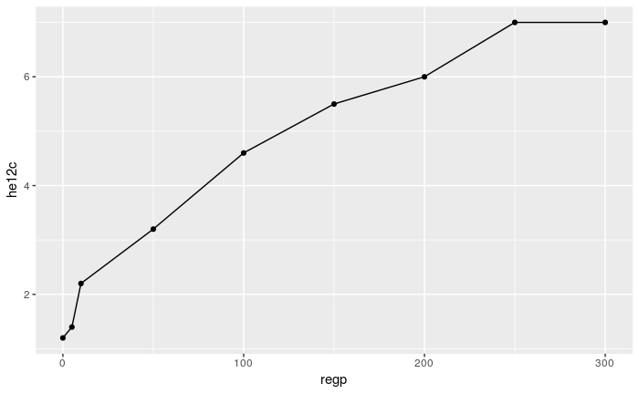

```r
ggplot(cur, aes(regp, he12c)) + geom_line() + geom_point()
```

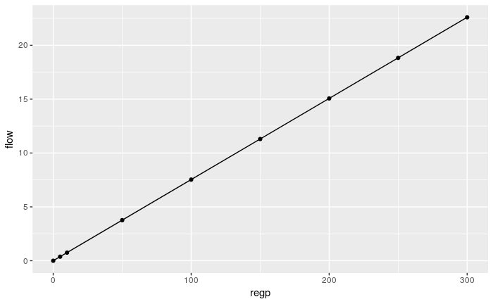

```r
ggplot(cur, aes(regp, flow)) + geom_line() + geom_point()
```

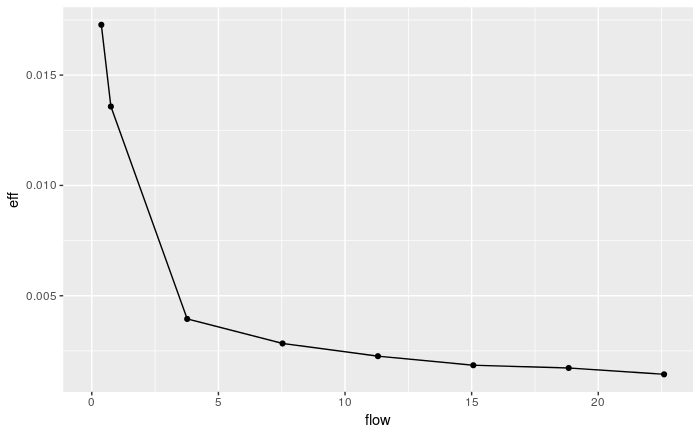

```r
ggplot(cur, aes(flow, eff)) + geom_line() + geom_point()
```

Currents were very stable after an initial burn in of ~10m. Initial current started at ~12uA without gas on target and decayed (roughly) exponentially to a minimum around 1.2uA.

```r
data %>% filter(Pos %in% c(11,12)) %>% ggplot(aes(ts, he12C, color = Pos)) + geom_line() + geom_point() + ylim(c(0,8))
```

[output not shown]

## Ratios

### Summary table

```r
data.s <- data %>% group_by(Pos) %>% summarize(c1412.m = mean(X14.12he),
                                         c1412.s = sd(X14.12he),
                                         c1412.sdr = c1412.s/c1412.m,
                                         c1412.se = se(X14.12he),
                                         c1412.ser = c1412.se/c1412.m,
                                         counts = sum(CntTotGT),
                                         interr = 1/sqrt(counts))
knitr::kable(data.s, digits = 4)
```

[output not shown]

### Plots

Boxplots of modern and dead samples. Ratios were essentially stable over time. Positions < 10 are solid samples run for comparison.

#### Modern

```r
data %>% filter(X14.12he > .4) %>% ggplot(aes(Pos, X14.12he, color = Num)) +
        geom_boxplot()
```

[output not shown]

#### Dead

```r
data %>% filter(X14.12he < .4) %>% ggplot(aes(Pos, X14.12he, color = Num)) +
        geom_boxplot()
```

[output not shown]

# Second Day

```r
#
data2 <- readResfile("/mnt/shared/USAMS/Results/USAMS040317R.txt") %>%
  filter(Pos == 13) %>%
  mungeResfile()
# Assign Run numbers
counter <- 0
Run <- c(1:190)
for (i in 1:nrow(data2)) {
  if (data2$Meas[i] == 1) {
    counter <- counter + 1
  }
  Run[i] <- counter
}
data2$Run <- Run
# Load pressure data
pres <- read.csv("USAMS040317Pressure.csv")
pres$Run <- as.numeric(row.names(pres))
# Join to run data
data2 <- inner_join(data2, pres) %>%
  mutate(flow = flowcalc(Bottle),
         eff = hgis_eff(flow, he12C))
data2
```

| Run.Completion.Time | Pos | Meas | Sample.Name | Num | Cycles | le12C | le13C | he12C | he13C | CntTotH | CntTotS | CntTotGT | X13.12he | X14.12he | ts | ce | cor1412he | Run | Bottle | Source | flow | eff |
| --- | --- | --- | --- | --- | --- | --- | --- | --- | --- | --- | --- | --- | --- | --- | --- | --- | --- | --- | --- | --- | --- | --- |
| Mon Apr 03 14:39:25 2017 | 13 | 1 | Gas Target | S | 300.9905 | -1.507928 | -1.650682e-07 | 1.857212 | 1.927412e-08 | 3010 | 3010 | 99 | 0.01037798 | 0.8511470 | 2017-04-03 14:39:25 | 0.10050378 | 7.902762 | 1 | 0 | NA | 0.000000 | NA |
| Mon Apr 03 14:39:57 2017 | 13 | 2 | Gas Target | S | 300.5837 | -1.505256 | -1.616293e-07 | 1.846250 | 1.913222e-08 | 3006 | 3006 | 105 | 0.01036275 | 0.9093210 | 2017-04-03 14:39:57 | 0.09759001 | 8.467733 | 1 | 0 | NA | 0.000000 | NA |
| Mon Apr 03 14:40:28 2017 | 13 | 3 | Gas Target | S | 300.6171 | -1.502206 | -1.692433e-07 | 1.843456 | 1.912164e-08 | 3006 | 3006 | 116 | 0.01037271 | 1.0059940 | 2017-04-03 14:40:28 | 0.09284767 | 9.349985 | 1 | 0 | NA | 0.000000 | NA |
| Mon Apr 03 14:41:00 2017 | 13 | 4 | Gas Target | S | 300.6731 | -1.494496 | -1.577156e-07 | 1.840838 | 1.914321e-08 | 3007 | 3007 | 104 | 0.01039918 | 0.9030402 | 2017-04-03 14:41:00 | 0.09805807 | 8.350431 | 1 | 0 | NA | 0.000000 | NA |
| Mon Apr 03 14:41:32 2017 | 13 | 5 | Gas Target | S | 300.5816 | -1.494230 | -1.669079e-07 | 1.836647 | 1.904131e-08 | 3006 | 3006 | 111 | 0.01036743 | 0.9663149 | 2017-04-03 14:41:32 | 0.09491580 | 8.990347 | 1 | 0 | NA | 0.000000 | NA |
| Mon Apr 03 14:42:04 2017 | 13 | 6 | Gas Target | S | 300.5827 | -1.492246 | -1.618532e-07 | 1.834994 | 1.911652e-08 | 3006 | 3006 | 93 | 0.01041776 | 0.8103415 | 2017-04-03 14:42:04 | 0.10369517 | 7.466540 | 1 | 0 | NA | 0.000000 | NA |
| Mon Apr 03 14:42:36 2017 | 13 | 7 | Gas Target | S | 300.5872 | -1.499999 | -1.657776e-07 | 1.836146 | 1.907186e-08 | 3006 | 3006 | 111 | 0.01038690 | 0.9665607 | 2017-04-03 14:42:36 | 0.09491580 | 8.958952 | 1 | 0 | NA | 0.000000 | NA |
| Mon Apr 03 14:43:08 2017 | 13 | 8 | Gas Target | S | 300.6172 | -1.494560 | -1.600084e-07 | 1.837431 | 1.901308e-08 | 3006 | 3006 | 110 | 0.01034764 | 0.9570875 | 2017-04-03 14:43:08 | 0.09534626 | 8.938590 | 1 | 0 | NA | 0.000000 | NA |
| Mon Apr 03 14:43:40 2017 | 13 | 9 | Gas Target | S | 300.5904 | -1.489601 | -1.679210e-07 | 1.823173 | 1.894766e-08 | 3006 | 3006 | 84 | 0.01039268 | 0.7366480 | 2017-04-03 14:43:40 | 0.10910895 | 6.820322 | 1 | 0 | NA | 0.000000 | NA |
| Mon Apr 03 14:44:12 2017 | 13 | 10 | Gas Target | S | 300.5692 | -1.484781 | -1.569265e-07 | 1.831885 | 1.897341e-08 | 3006 | 3006 | 122 | 0.01035731 | 1.0648800 | 2017-04-03 14:44:12 | 0.09053575 | 9.926742 | 1 | 0 | NA | 0.000000 | NA |

[output cut: 180 more lines]

```r
# summarize
d2.s <- data2 %>% group_by(Run, Bottle, Source) %>% summarize(le12C = mean(le12C),
                                              he12C = mean(he12C),
                                              C1412he = mean(X14.12he),
                                              cor1412he = mean(cor1412he),
                                              eff = mean(eff))
```

[figure not shown]